# Fenstermaker Individual Project

Matthew Fenstermaker

**Load in Libraries**

```r
library(tswge)
```

**Read in Data**

```r
data = read.csv("tourismData.csv")
```

**Create the TS from data**

```r
data.ts <- ts(data$x, start = c(1985,1), end = c(2004, 12), frequency = 12)
```

**Create Plots for new T-series**

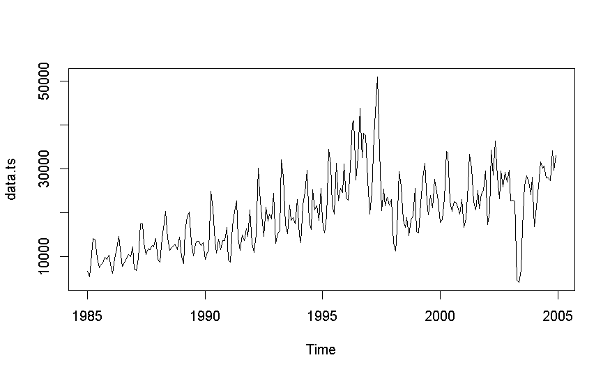

```r
plot(data.ts)
```

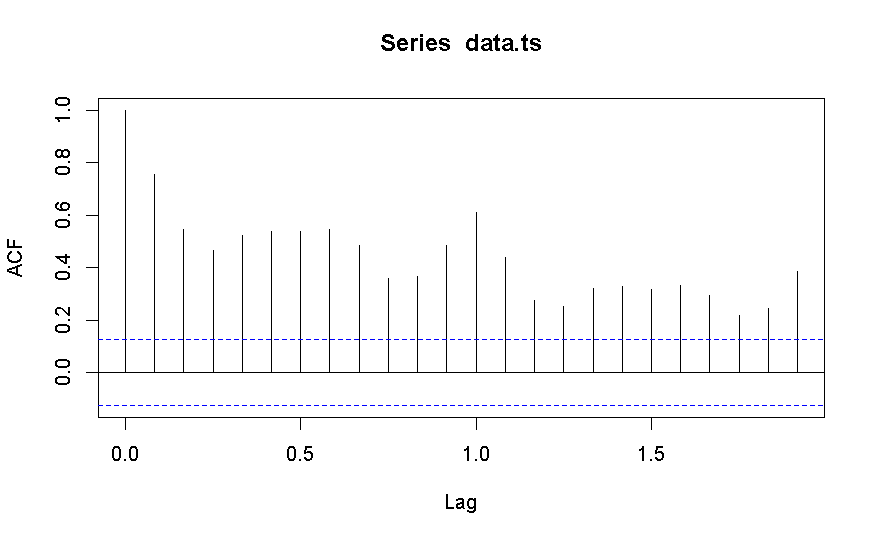

```r
acf(data.ts)
```

[output not shown]

[output cut: 68 more lines]

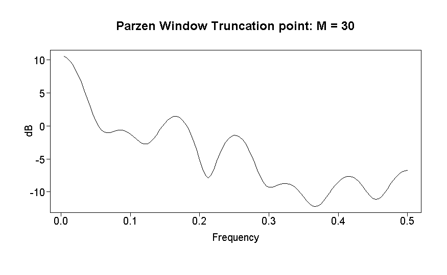

```r
parzen.wge(data.ts)
```

**Comments about the plots for the data**

*The graph seems to have increasing variability going towards 1997-1998 where it sees a sharp peak then goes back down to the original increase in variability. It is worth noting how the graph shows a large dip around the 2003-2004 range.*

*The ACF shows that the data does not have a lot of movement, and that the ACF never goes under 0 and all lag values are significant, meaning that there is a possibility for a seasonal aspect to this data.*

*Looking at the Parzen graph, it seems to have peaks at 0, .1667, .25, and even a smaller one around .5. This can show possible values for a seasonal aspect of this graph.*

*Create Holt Winters Forecast*

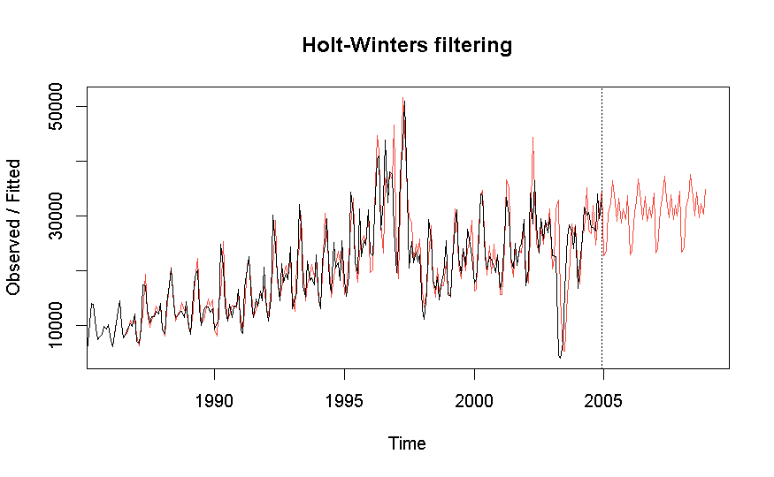

```r
HW = HoltWinters(data.ts,seasonal="multiplicative")
HW.pred = predict(HW,n.ahead=48)
plot(HW,HW.pred)
```

*Forecasting with an ARMA model*

**Finding the best values for p and q**

```r
ARMA = aic.wge(data.ts,p=0:18,q=0:8,type="aic")
ARMA
```

```
$type
[1] "aic"

$value
[1] 16.62163

$p
[1] 11

$q
[1] 8

$phi
 [1]  0.25892301 -0.21950109 -0.32571629  0.31440463  0.32398576  0.12069448  0.15359162  0.62702269
 [9] -0.54306690  0.11077359  0.09407949

$theta
[1] -0.4374402 -0.6895277 -0.7744906 -0.3420367  0.2018329  0.2014087  0.0172141  0.7707733

$xbar
[1] 19910.67

$vara
[1] 14005559
```

**Finding the factors for the newfound model**

```r
est.arma.wge(data.ts,p=11,q=8)
```

```
Coefficients of AR polynomial:
0.2589 -0.2195 -0.3257 0.3144 0.3240 0.1207 0.1536 0.6270 -0.5431 0.1108 0.0941

                           AR Factor Table
Factor                 Roots                Abs Recip    System Freq
1+0.9991B             -1.0009               0.9991       0.5000
1-0.9912B+0.9944B^2    0.4984+-0.8702i      0.9972       0.1672
1-0.9861B              1.0140               0.9861       0.0000
1-0.0105B+0.9625B^2    0.0055+-1.0193i      0.9811       0.2491
1+1.4431B+0.9318B^2   -0.7743+-0.6882i      0.9653       0.3844
1-1.0066B+0.3649B^2    1.3793+-0.9155i      0.6041       0.0933
1+0.2934B             -3.4082               0.2934       0.5000




Coefficients of MA polynomial:
-0.4374 -0.6895 -0.7745 -0.3420 0.2018 0.2014 0.0172 0.7708

                              MA FACTOR TABLE
Factor                 Roots                Abs Recip    System Freq
1+1.4390B+0.9999B^2   -0.7196+-0.6945i      0.9999       0.3778
1-0.2108B+0.9985B^2    0.1055+-0.9952i      0.9993       0.2332
1+0.9899B             -1.0103               0.9899       0.5000
1-0.9503B+0.9393B^2    0.5059+-0.8993i      0.9692       0.1684
1-0.8304B              1.2043               0.8304       0.0000


$phi
 [1]  0.25892301 -0.21950109 -0.32571629  0.31440463  0.32398576  0.12069448  0.15359162  0.62702269
 [9] -0.54306690  0.11077359  0.09407949

$theta
[1] -0.4374402 -0.6895277 -0.7744906 -0.3420367  0.2018329  0.2014087  0.0172141  0.7707733

$res
  [1]  -1407.00476   -922.86873   -238.13600   -328.41017    362.81559  -1015.88548   -319.92000
  [8]   -496.21480  -1886.58345  -1610.14648  -1925.40427    548.75780   1146.74522  -1037.28067
 [15]   -614.58669  -2143.43022   3072.00019    329.19725  -1061.37578  -1314.83316   -362.91628
 [22]   -947.17882   -998.34136   1114.28833  -1950.58220    865.73156   -165.10385   2882.68688
```

[output cut: 38 more lines]

```
$aic
[1] 16.62163

$aicc
[1] 17.64763

$bic
[1] 16.91168

$se.phi
 [1] 0.016350953 0.009236268 0.016087671 0.010432415 0.004670336 0.004323969 0.004454046 0.007305013
 [9] 0.015887027 0.006195056 0.008275972

$se.theta
[1] 0.01365016 0.02233290 0.04604809 0.06179550 0.06438234 0.03528035 0.01951401 0.01212349
```

**Using the ARMA(11,8) model to compare against the original data set**

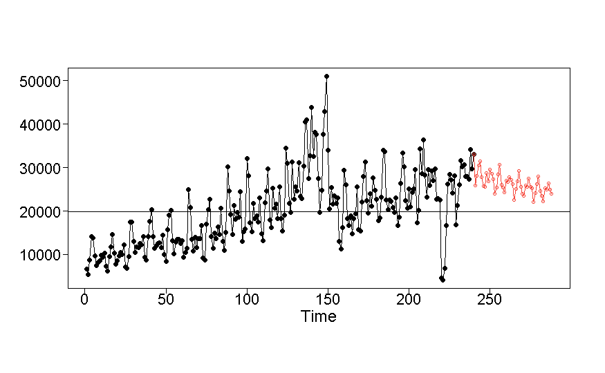

```r
fore11.8= fore.arma.wge(data.ts,phi= ARMA$phi,theta= ARMA$theta,n.ahead= 48,limits= FALSE)
abline(h=mean(data.ts))
```

**It is apparent that the forecasted graph holds the same trend, but is showing that it is decreasing instead of the trend of increasing over time. It looks as if the forecast is trying to come closer to the mean while still maintaining the basic trend shape.**

*Forecast from a Seasonal Model*

```r
dataFit = est.ar.wge(data.ts,p=16,method="burg")
```

```
Coefficients of AR polynomial:
0.6927 0.0453 -0.0673 0.0889 -0.0487 0.0491 0.1890 -0.0274 -0.1444 0.0566 -0.0270 0.5172 -0.3352 -0.2055 0.0587 0.0907

                           AR Factor Table
Factor                 Roots                Abs Recip    System Freq
1+0.0196B+0.9646B^2   -0.0102+-1.0181i      0.9821       0.2516
1-0.9919B+0.9640B^2    0.5145+-0.8790i      0.9819       0.1657
1-0.9741B              1.0266               0.9741       0.0000
1+0.9482B             -1.0547               0.9482       0.5000
1+1.6081B+0.8780B^2   -0.9157+-0.5481i      0.9370       0.4142
1+0.8328B+0.8635B^2   -0.4822+-0.9621i      0.9293       0.3239
1-1.4981B+0.8405B^2    0.8912+-0.6289i      0.9168       0.0978
1-1.4984B+0.5992B^2    1.2505+-0.3246i      0.7741       0.0404
1+0.8613B+0.2765B^2   -1.5578+-1.0912i      0.5258       0.4027
```

*The data seems to fit that of a $(1-B)^12$ model. Let’s create a difference of the data and look at what particularly it looks like.*

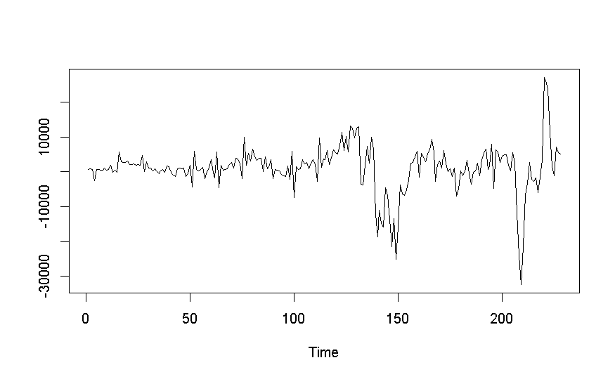

```r
data.diff=artrans.wge(data.ts,phi.tr = c(rep(0,11),1),plot=F)
plot(data.diff,type="l",xlab="Time",ylab="")
```

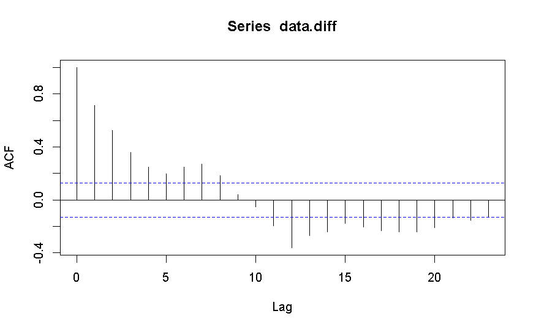

```r
acf(data.diff)
```

[output not shown]

[output cut: 64 more lines]

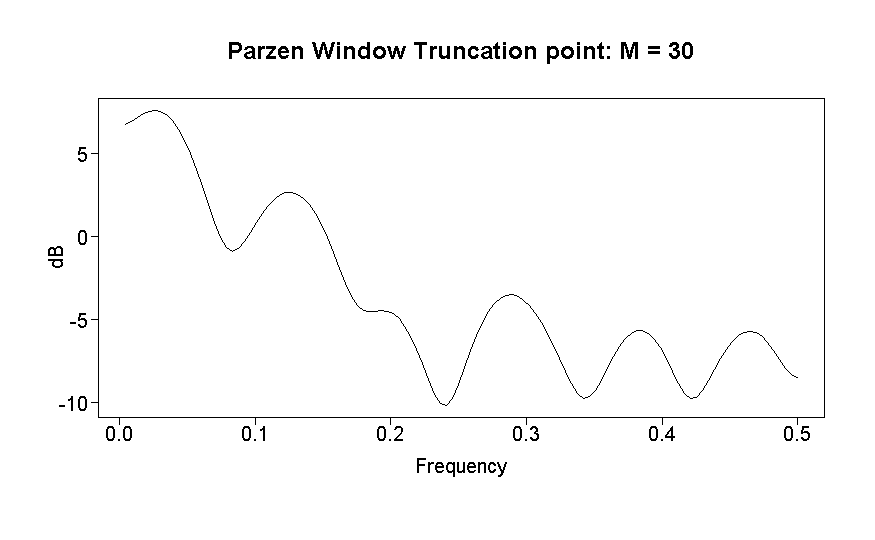

```r
parzen.wge(data.diff)
```

*The observed graphs allow us to make an assumption that the differenced seasoned graphs are in fact stationary, so we can fit an ARMA(p,q) model based off this.*

```r
ARMA2 = aic.wge(data.diff,p=0:18,q=0:8)
ARMA
```

```
$type
[1] "aic"

$value
[1] 16.62163

$p
[1] 11

$q
[1] 8

$phi
 [1]  0.25892301 -0.21950109 -0.32571629  0.31440463  0.32398576  0.12069448  0.15359162  0.62702269
 [9] -0.54306690  0.11077359  0.09407949

$theta
[1] -0.4374402 -0.6895277 -0.7744906 -0.3420367  0.2018329  0.2014087  0.0172141  0.7707733

$xbar
[1] 19910.67

$vara
[1] 14005559
```

```r
est.arma.wge(data.diff,p=15,q=4)
```

```
Coefficients of AR polynomial:
-0.5092 0.0080 -0.1274 -0.0869 0.3502 0.1424 0.1991 0.1458 0.0247 0.1539 0.0611 -0.5749 -0.3583 -0.0741 -0.0203

                           AR Factor Table
Factor                 Roots                Abs Recip    System Freq
1-0.5850B+0.9802B^2    0.2984+-0.9650i      0.9900       0.2023
1-1.3418B+0.9312B^2    0.7204+-0.7449i      0.9650       0.1277
1+1.4637B+0.9135B^2   -0.8012+-0.6729i      0.9557       0.3888
1-1.8653B+0.9050B^2    1.0305+-0.2073i      0.9513       0.0316
1+0.4436B+0.8814B^2   -0.2517+-1.0350i      0.9388       0.2880
1+1.7672B+0.8624B^2   -1.0246+-0.3312i      0.9286       0.4502
1+0.5128B             -1.9500               0.5128       0.5000
1+0.1139B+0.0689B^2   -0.8273+-3.7201i      0.2624       0.2848




Coefficients of MA polynomial:
-1.2028 -0.9517 -0.9016 -0.7428

                              MA FACTOR TABLE
Factor                 Roots                Abs Recip    System Freq
1+1.6684B+0.9290B^2   -0.8980+-0.5197i      0.9638       0.4165
1-0.4656B+0.7996B^2    0.2912+-1.0797i      0.8942       0.2081


$phi
 [1] -0.509176204  0.007998369 -0.127353257 -0.086889339  0.350164936  0.142412304  0.199059709
 [8]  0.145755134  0.024739345  0.153895358  0.061101731 -0.574944334 -0.358265202 -0.074132135
[15] -0.020250287

$theta
[1] -1.2028115 -0.9517191 -0.9015738 -0.7428123

$res
  [1]    872.00804   -478.33539    607.78023  -2441.54276   1569.81989    186.26463   -824.91813
  [8]    785.29624   -919.50987    853.61786   -708.25510     92.38218   -883.53183    194.88225
 [15]    203.16910   2711.11360   -350.90873    -28.39195    512.39372   1402.86722   -768.51405
 [22]   -172.73650   -388.99873    784.46906    116.50926  -1218.78688   2622.75140   -666.50033
 [29]   2424.61260  -1458.44854   -992.88544    277.95497    445.11277   -298.37213  -1457.49378
```

[output cut: 35 more lines]

```
$aic
[1] 16.60322

$aicc
[1] 17.63167

$bic
[1] 16.90404

$se.phi
 [1] 0.021555960 0.018129113 0.012732909 0.006898637 0.004800070 0.004274134 0.004622583 0.005852206
 [9] 0.005849424 0.004819543 0.004444254 0.004344512 0.013980386 0.013636003 0.007738473

$se.theta
[1] 0.017660233 0.034134816 0.013878957 0.005174617
```

**The best predicting model is found to be:**

$(1+0.5092B-0.0080B^2+0.1274B^3+0.0869B^4-0.3502B^5-0.1424B^6-0.1991B^7-0.1458B^8-0.0247B^9-0.1539B^{10}-0.0611B^{11}+0.5749B^{12}+0.3583B^{13}+0.0741B^{14}+0.0203B^{15})(X_t-984.7632)=(1+1.2028B+0.9517B^2+0.9016B^3+0.7428B^4)a_t$

**which is ARMA(15,4)**

**Using the ARMA(15,4) model to compare against the seasonally differenced data**

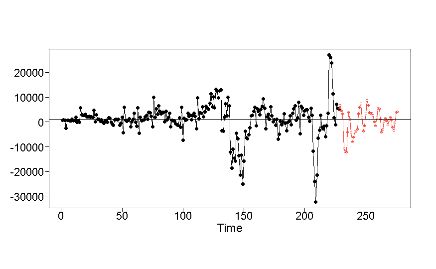

```r
fore15.4= fore.arma.wge(data.diff,phi= ARMA2$phi,theta= ARMA2$theta,n.ahead= 48,limits= FALSE)
abline(h=mean(data.diff))
```